# L5 - Combining Data

## Lecture Goals

- Learn how to:
  - Work w/ relational data
  - Join/merge data-frames
  - Append/bind data-frames
- Readings
  - [R4DS](http://r4ds.had.co.nz/): ch. 13
  - Data Wrangling [cheatsheet](https://www.rstudio.com/wp-content/uploads/2015/02/data-wrangling-cheatsheet.pdf)

## Relational Data

- **Databases** are organized collections of data
  - Implemented through some *DB Management Systems* (e.g. Oracle)
- Majority of DBs use **relational model** of data ogranization
  - Data live in multiple inter-related tables
  - *SQL* is standard language for managing relational DB's

## Relational Data

- Sample university database

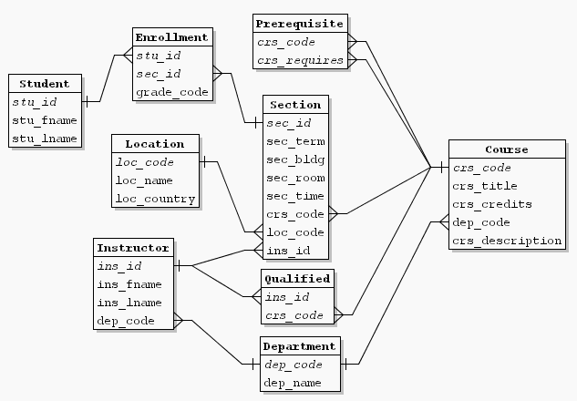

## Keys

- Tables are connected through variable(s) called **keys**
  - Keys are used to identify/relate observations
- Two types of keys
  - **Primary** keys *uniquely* identify observations *within a table*
  - **Foreign** keys *associate* observations with those in *other tables*

## Relationships

- Primary/foreign key pairs establish **relationships** between tables
- Three types of relationships
  - **One-to-one**: primary-primary pair
  - **One-to-many**: primary-foreign pair
  - **Many-to-many**: (primary-foreign) [*junction table*] (foreign-primary) pairs

## Mutating Joins

- Expand left/right table with variables from other table, matching observations where possible

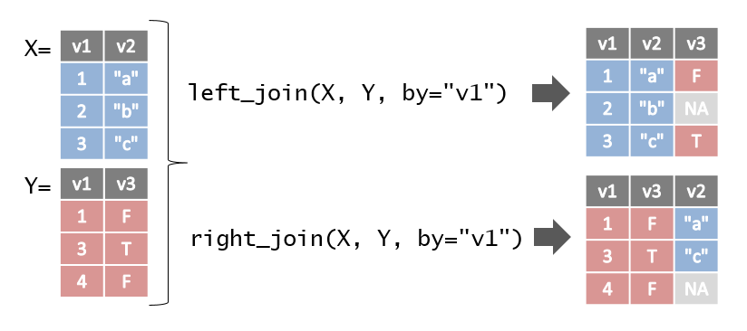

## Mutating Joins

- Merge tables' variables, keeping *only matching* (inner join) or *all* (full join) observations

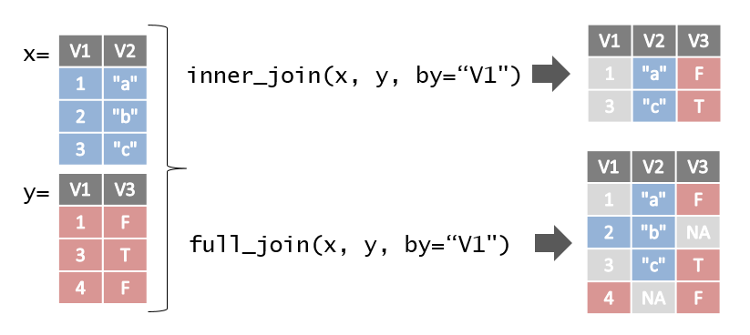

## Filtering Joins

- Filter observations in one table, based on whether they *match* (semi join) or *not* (anti join) with other table

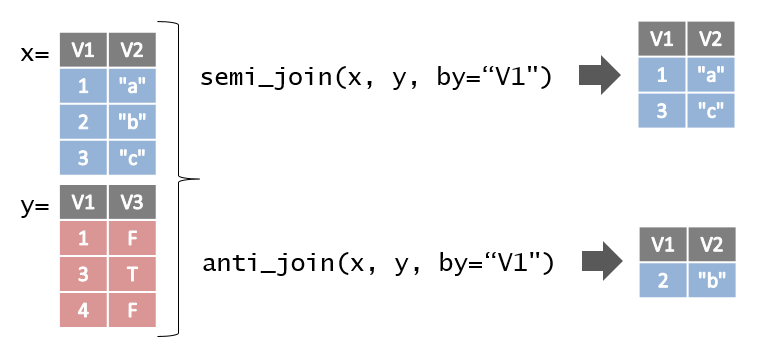

## Set Operations

- Operations on sets or observations (rows) with the same variables

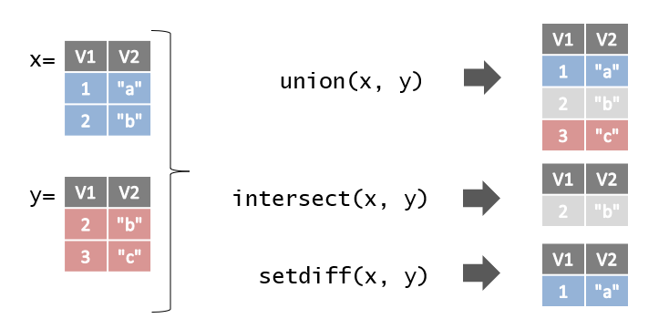

## Binding

- Append table rows/columns

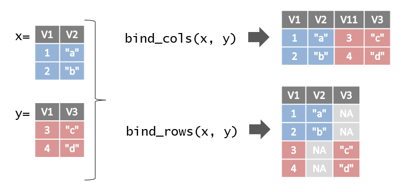